# Exploratory Data Analysis with R by Artem Oppermann

## 1. Introduction

This report explores a dataset containing 1,599 red wines with 11 variables on the chemical properties of the wine. At least 3 wine experts rated the quality of each wine, providing a rating between 0 (very bad) and 10 (excellent). The report focuses on the topic which chemical properties influence the quality of red wines.

## 2. Exploring The Dataset

To gain an overview over the data I do a quick examination of the basic structure and shema of the dataset.

```
## 'data.frame':    1599 obs. of  13 variables:
##  $ X                   : int  1 2 3 4 5 6 7 8 9 10 ...
##  $ fixed.acidity       : num  7.4 7.8 7.8 11.2 7.4 7.4 7.9 7.3 7.8 7.5 ...
##  $ volatile.acidity    : num  0.7 0.88 0.76 0.28 0.7 0.66 0.6 0.65 0.58 0.5 ...
##  $ citric.acid         : num  0 0 0.04 0.56 0 0 0.06 0 0.02 0.36 ...
##  $ residual.sugar      : num  1.9 2.6 2.3 1.9 1.9 1.8 1.6 1.2 2 6.1 ...
##  $ chlorides           : num  0.076 0.098 0.092 0.075 0.076 0.075 0.069 0.065 0.073 0.071 ...
##  $ free.sulfur.dioxide : num  11 25 15 17 11 13 15 15 9 17 ...
##  $ total.sulfur.dioxide: num  34 67 54 60 34 40 59 21 18 102 ...
##  $ density             : num  0.998 0.997 0.997 0.998 0.998 ...
##  $ pH                  : num  3.51 3.2 3.26 3.16 3.51 3.51 3.3 3.39 3.36 3.35 ...
##  $ sulphates           : num  0.56 0.68 0.65 0.58 0.56 0.56 0.46 0.47 0.57 0.8 ...
##  $ alcohol             : num  9.4 9.8 9.8 9.8 9.4 9.4 9.4 10 9.5 10.5 ...
##  $ quality             : int  5 5 5 6 5 5 5 7 7 5 ...
```

```
##        X          fixed.acidity   volatile.acidity  citric.acid
##  Min.   :   1.0   Min.   : 4.60   Min.   :0.1200   Min.   :0.000
##  1st Qu.: 400.5   1st Qu.: 7.10   1st Qu.:0.3900   1st Qu.:0.090
##  Median : 800.0   Median : 7.90   Median :0.5200   Median :0.260
##  Mean   : 800.0   Mean   : 8.32   Mean   :0.5278   Mean   :0.271
##  3rd Qu.:1199.5   3rd Qu.: 9.20   3rd Qu.:0.6400   3rd Qu.:0.420
##  Max.   :1599.0   Max.   :15.90   Max.   :1.5800   Max.   :1.000
##  residual.sugar     chlorides       free.sulfur.dioxide
##  Min.   : 0.900   Min.   :0.01200   Min.   : 1.00
##  1st Qu.: 1.900   1st Qu.:0.07000   1st Qu.: 7.00
##  Median : 2.200   Median :0.07900   Median :14.00
##  Mean   : 2.539   Mean   :0.08747   Mean   :15.87
##  3rd Qu.: 2.600   3rd Qu.:0.09000   3rd Qu.:21.00
##  Max.   :15.500   Max.   :0.61100   Max.   :72.00
##  total.sulfur.dioxide    density             pH          sulphates
##  Min.   :  6.00       Min.   :0.9901   Min.   :2.740   Min.   :0.3300
##  1st Qu.: 22.00       1st Qu.:0.9956   1st Qu.:3.210   1st Qu.:0.5500
##  Median : 38.00       Median :0.9968   Median :3.310   Median :0.6200
##  Mean   : 46.47       Mean   :0.9967   Mean   :3.311   Mean   :0.6581
##  3rd Qu.: 62.00       3rd Qu.:0.9978   3rd Qu.:3.400   3rd Qu.:0.7300
##  Max.   :289.00       Max.   :1.0037   Max.   :4.010   Max.   :2.0000
##     alcohol         quality
##  Min.   : 8.40   Min.   :3.000
##  1st Qu.: 9.50   1st Qu.:5.000
##  Median :10.20   Median :6.000
##  Mean   :10.42   Mean   :5.636
##  3rd Qu.:11.10   3rd Qu.:6.000
##  Max.   :14.90   Max.   :8.000
```

The dataset consists of 13 variables, with 1599 observations. The variable X seems to be an ID for each sort of wine. Although the experts could rate the wine on a scale 0-10 in this data set there are only wines on a quality scale of 3-8, with the mean quality of 5.636.

## 3. Univariate Analysis

Since I focus on the quality of the wines I want to gain a visual overview over the overall quality.

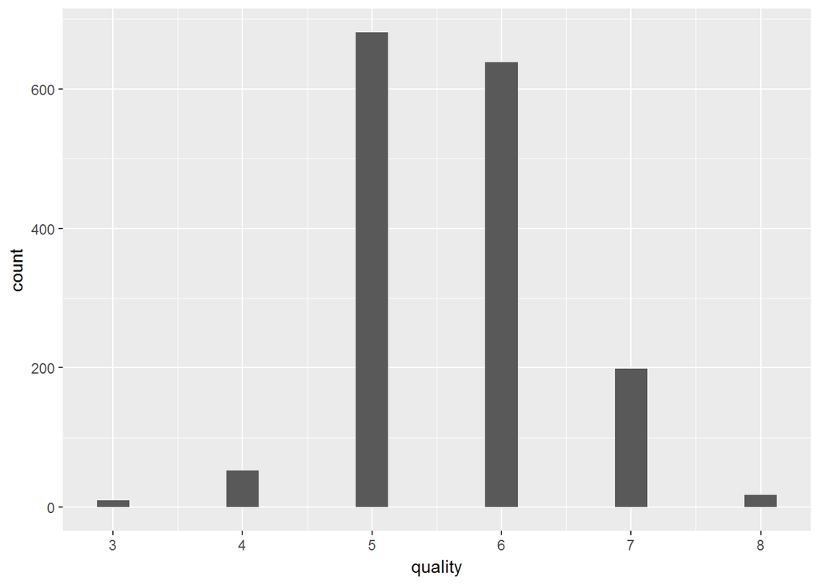

In this histogram can be observed that most wine have a quality rating of 5 and 6. The best/worst quality rating in the dataset have only a very few wines.

To gain an overview of the 11 chemical propeties I am plotting each of those in a histogram.

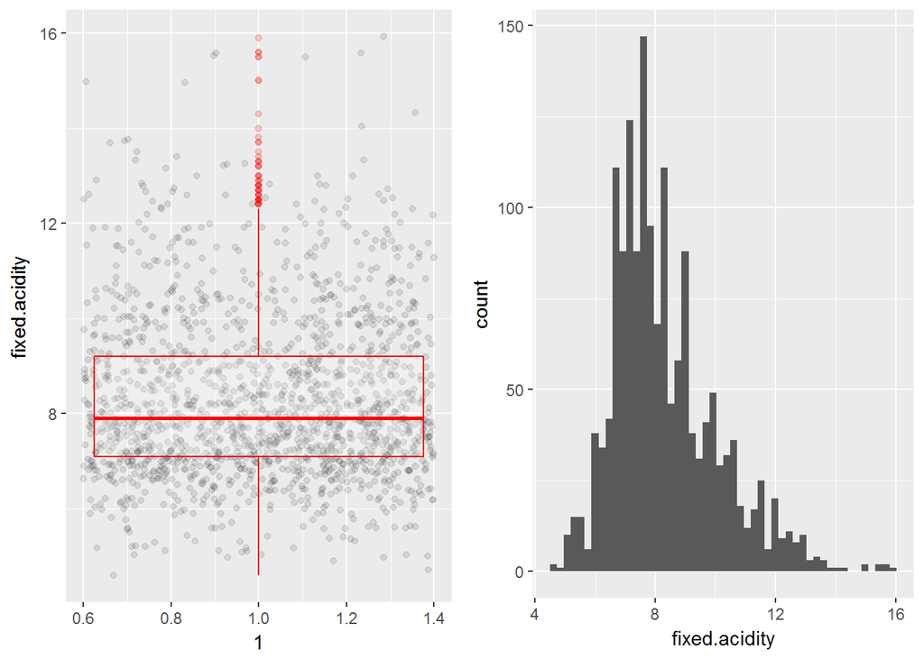

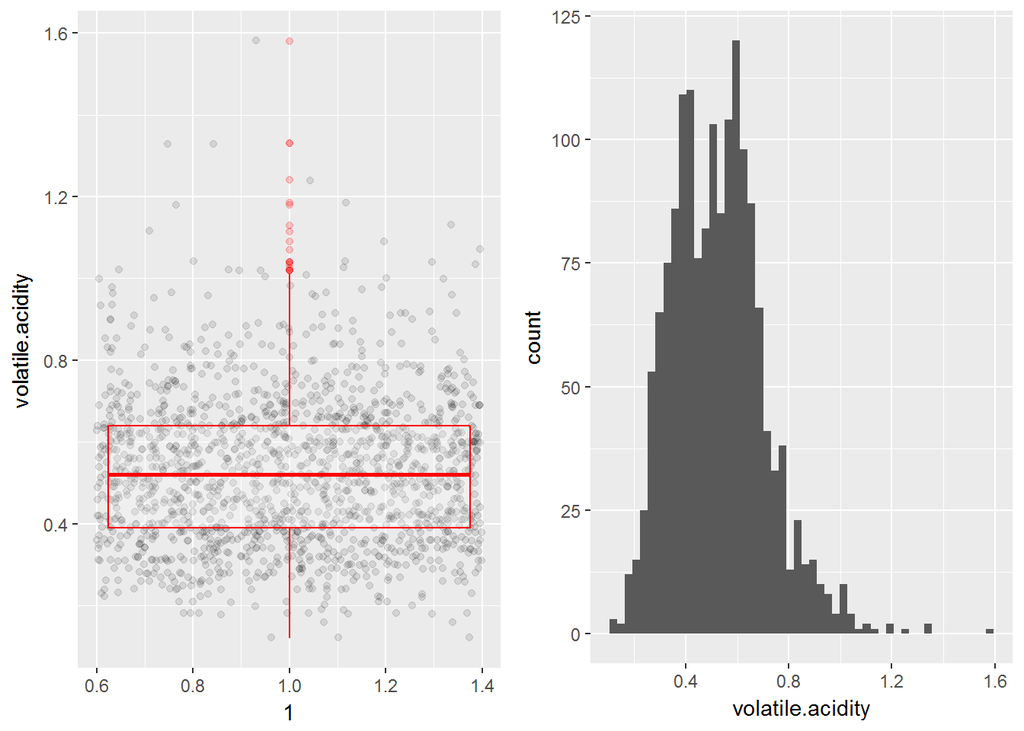

The plot shows the distribution of volatile acidity. The shape can be approximated as one of a normal distribution. The median of the distribution is around 0.5. Above the value of 1.0 there are some big outliers.

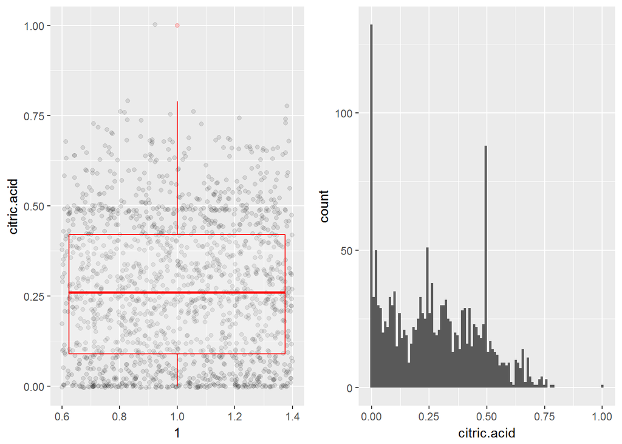

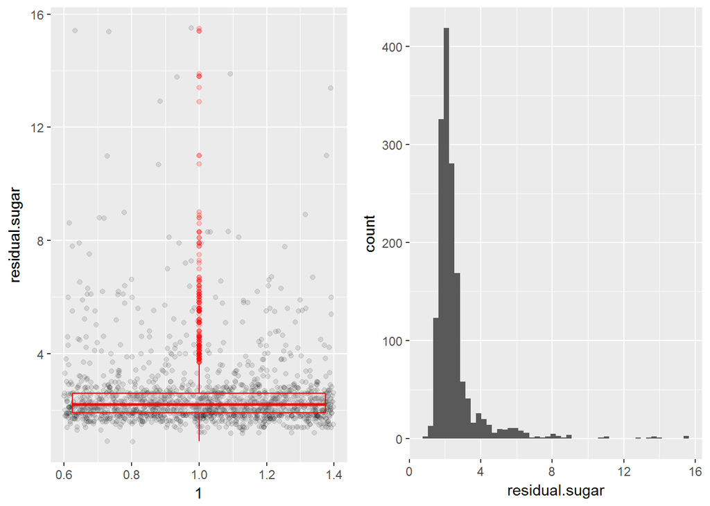

The plot shows the distribution of residual sugar. The shape can be approximated as one of a normal distribution with a very small standard deviation. The median of the distribution is around 2.0. Above the value of 3 there are many big outliers.

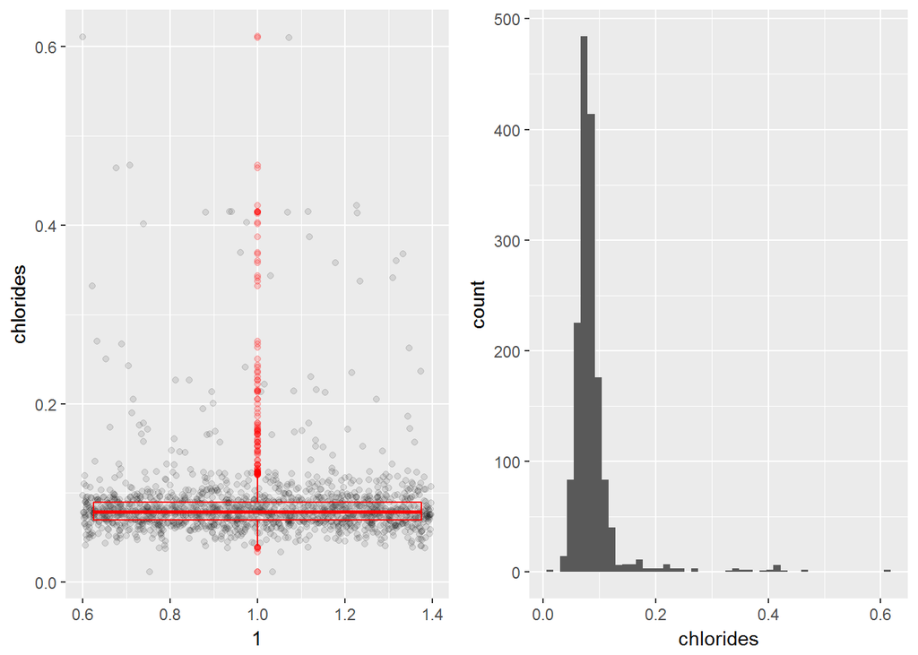

The plot shows the distribution of chlorides. The shape can be approximated as one of a normal distribution with a very small standard deviation. The median of the distribution is around 0.1. Above the value of roughly 0.11 and below 0.5 there are many big outliers.

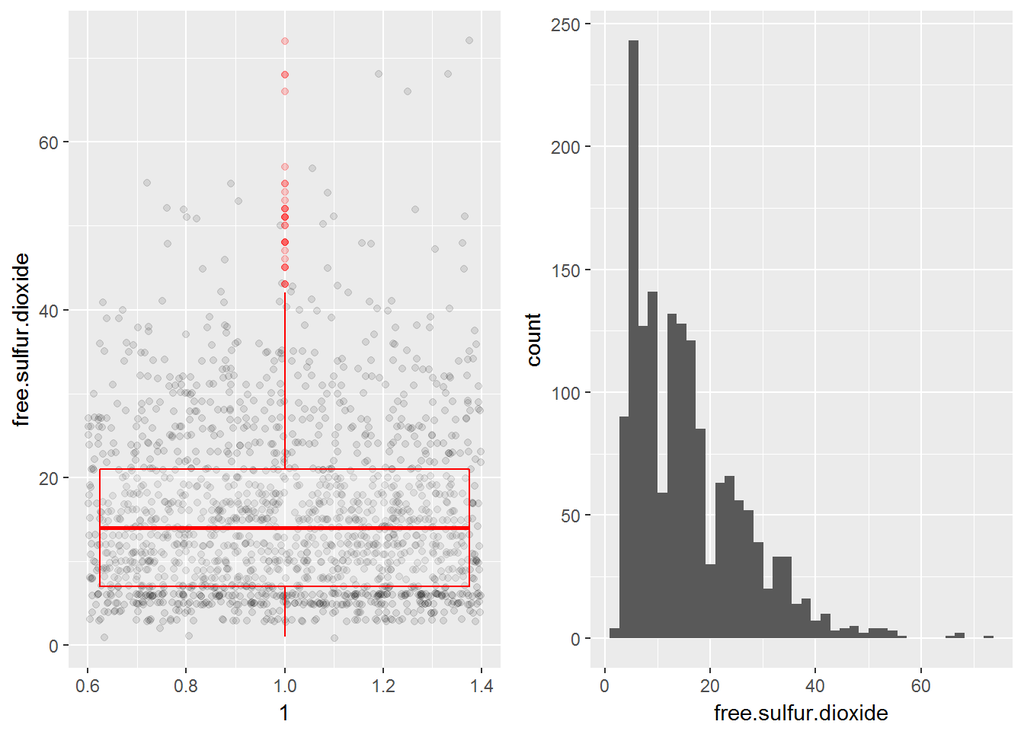

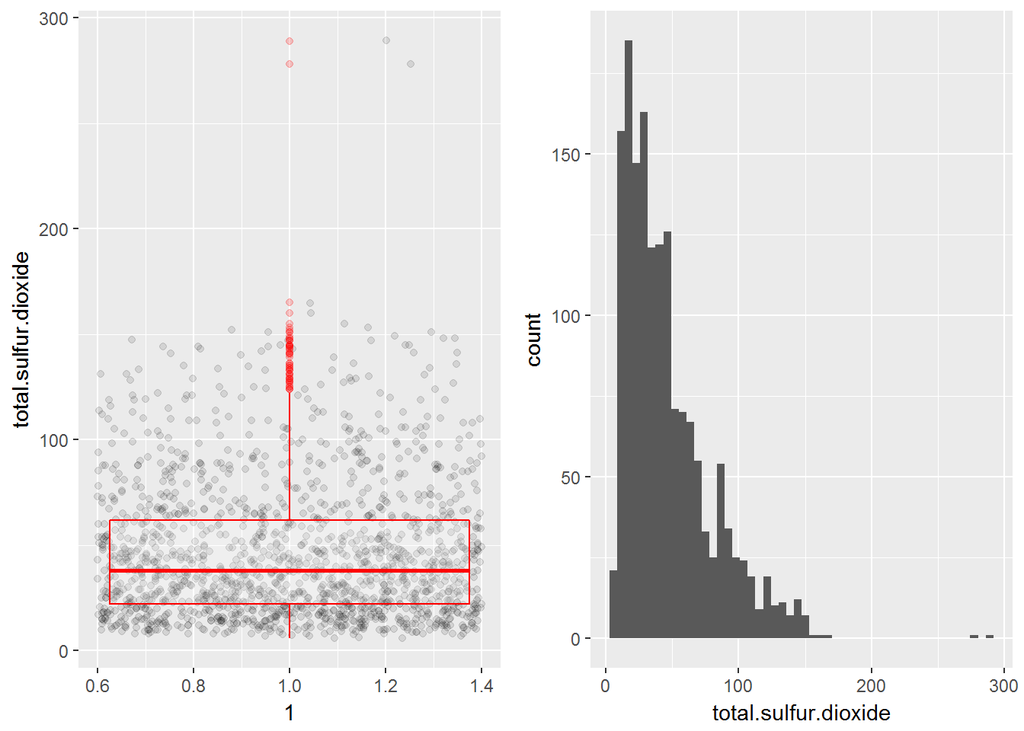

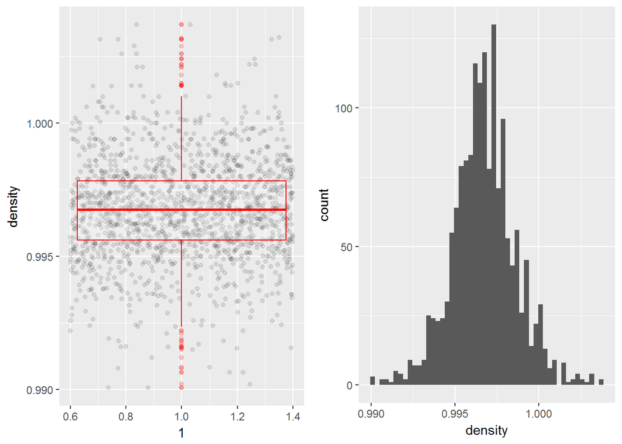

The plot shows the distribution of the density. The shape can be approximated as one of a normal distribution. The median of the distribution is around 0.996. Above approximately 1.0025 and below 0.9925 some big outliers can be found.

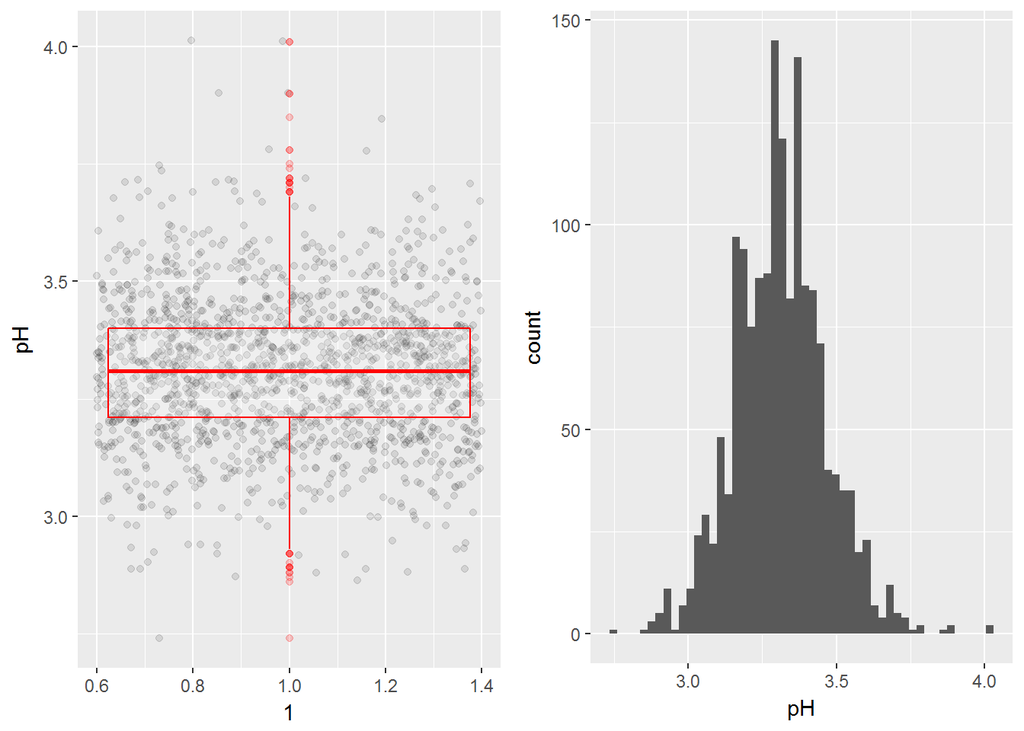

The plot shows the distribution of the pH. The shape can be approximated as one of a normal distribution. The median of the distribution is around 3.3. Above approximatly 3.8 and below 3.0 some big outliers can be found.

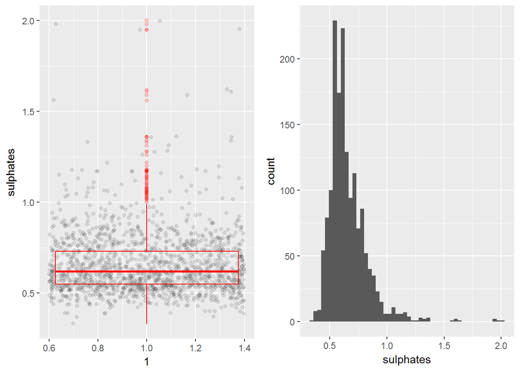

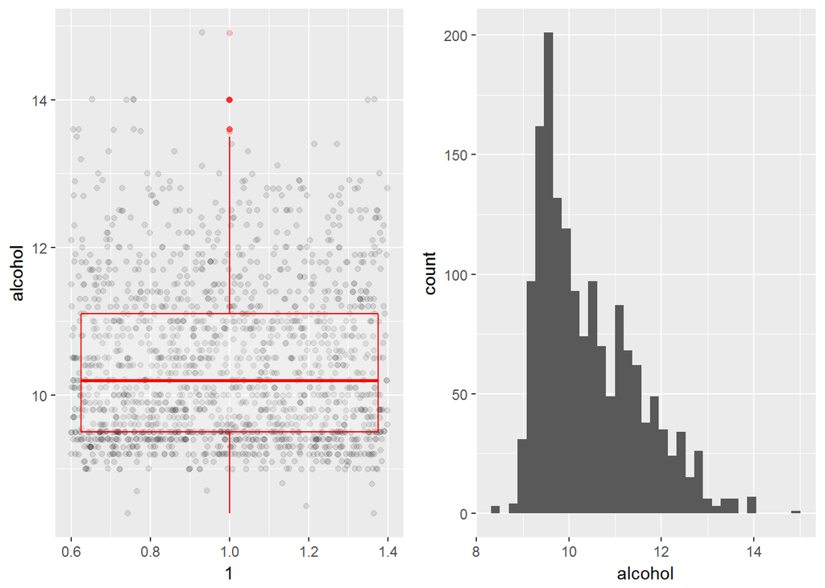

Since I do not have any background in wine producing I can not exclude any chemical property from beeing a feature of interest. In the following chapter I will examine every one of the chemical properties in regards to their influence on the wine quality.

## 4. Bivariate Analysis

In the next step I generate box plots of quality over the chemical variables. I expect to find some significant correlations between the quality and the chemical variables and also to identify chemical propertys that do not have any influence on the quality so I can exlude those for further analysis.

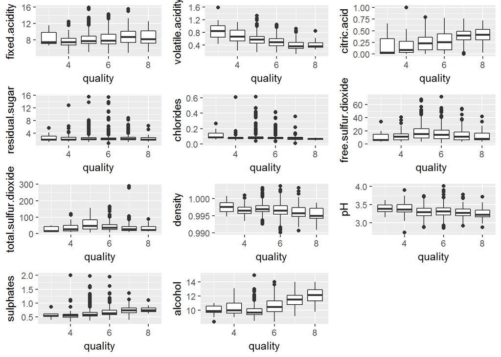

Indeed I got the results I hoped to find:

- Lower levels of volatily acidity, pH and density improve the wine quality
- Lower levels of fixed acidity, alcohol, sulphates and citric acid descrease the wine quality
- Free sulfur dioxide, total sulfur dioxide and residual sugar seem not to have any significant influence on the wine quality

For further examination I ploted the variables against each other to see whether any correlations can be noticed. I hope to find correlations between some variables that have an affect on the quality. The correlations would show the interplay of two variables and their concentration in the wine. I hope to find a common rule for what concentration of a chemical property should be used if there is already a particular amount of an other chemical property in the wine.

Since not all variables seemed to have correlations between each other, I only include plots to this report where a significant correlation can be observed.

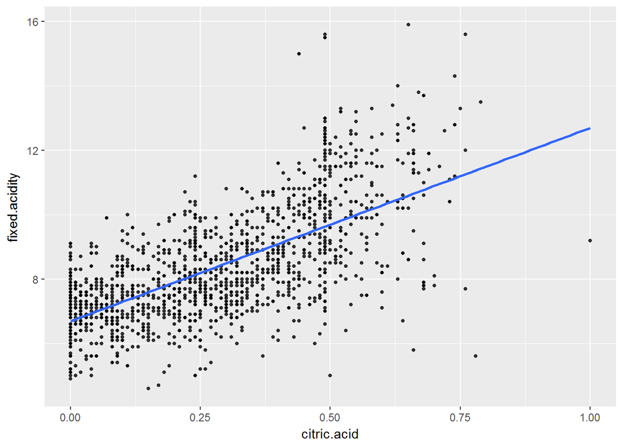

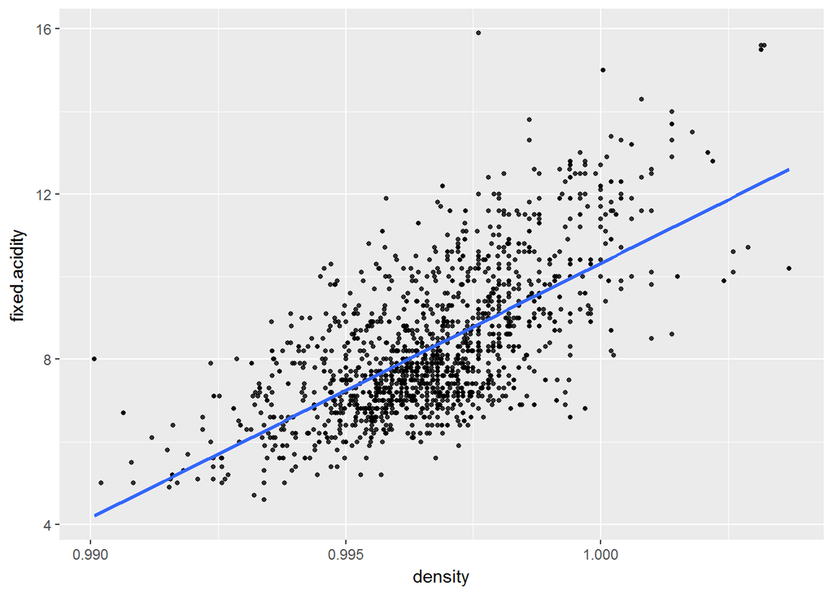

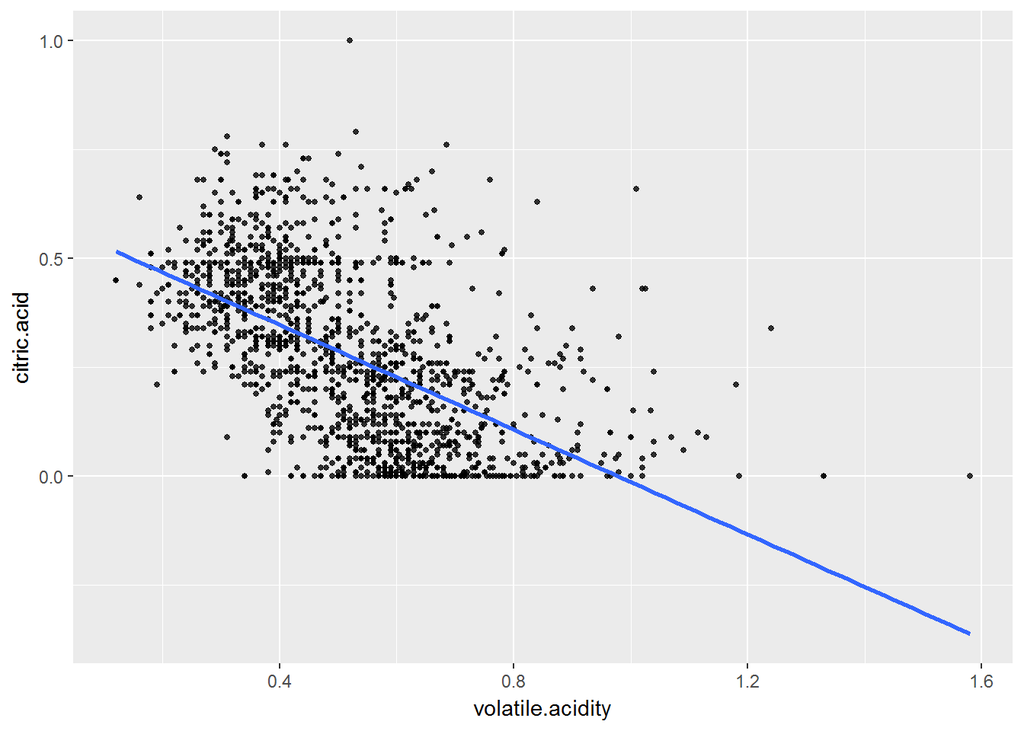

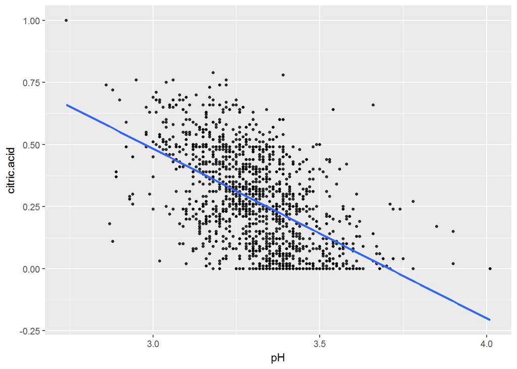

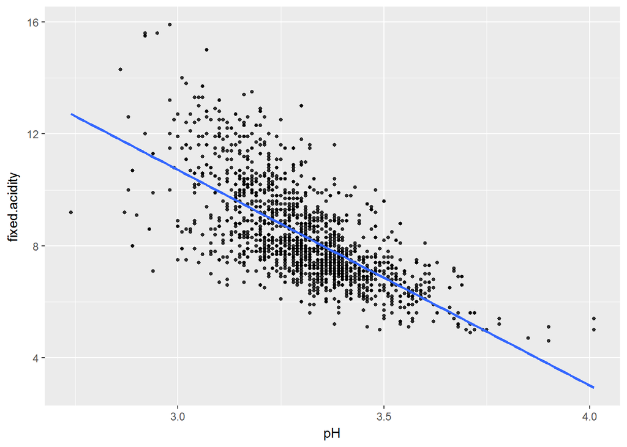

To quantify the correlation between the variables I use the Pearson’s product moment correlation coefficient.

```
##
##  Pearson's product-moment correlation
##
## data:  wine$citric.acid and wine$fixed.acidity
## t = 36.234, df = 1597, p-value < 2.2e-16
## alternative hypothesis: true correlation is not equal to 0
## 95 percent confidence interval:
##  0.6438839 0.6977493
## sample estimates:
##       cor
## 0.6717034
```

```
##
##  Pearson's product-moment correlation
##
## data:  wine$density and wine$fixed.acidity
## t = 35.877, df = 1597, p-value < 2.2e-16
## alternative hypothesis: true correlation is not equal to 0
## 95 percent confidence interval:
##  0.6399847 0.6943302
## sample estimates:
##       cor
## 0.6680473
```

```
##
##  Pearson's product-moment correlation
##
## data:  wine$volatile.acidity and wine$citric.acid
## t = -26.489, df = 1597, p-value < 2.2e-16
## alternative hypothesis: true correlation is not equal to 0
## 95 percent confidence interval:
##  -0.5856550 -0.5174902
## sample estimates:
##        cor
## -0.5524957
```

```
##
##  Pearson's product-moment correlation
##
## data:  wine$pH and wine$citric.acid
## t = -25.767, df = 1597, p-value < 2.2e-16
## alternative hypothesis: true correlation is not equal to 0
## 95 percent confidence interval:
##  -0.5756337 -0.5063336
## sample estimates:
##        cor
## -0.5419041
```

```
##
##  Pearson's product-moment correlation
##
## data:  wine$pH and wine$fixed.acidity
## t = -37.366, df = 1597, p-value < 2.2e-16
## alternative hypothesis: true correlation is not equal to 0
## 95 percent confidence interval:
##  -0.7082857 -0.6559174
## sample estimates:
##        cor
## -0.6829782
```

Although alcohol has a big influence on the wine quality no correlation with any of variables that have a major influence on the wine quality could be observed. I guess alcohol increases the quality of the wine independent of other chemical concentrations due to the intoxicating effect on people.

For further examination I will focus only on alcohol, citric acid, volatile acid and sulphates since these variables have the biggest affect on the wine quality. I will also exclude the pH variable because pH is only a numeric scale used to specify the acidity. I also exclude the density since it is only a physical property of the fluid based on the chemical concentration.

## 5. Multivariate Analysis

In this section I examine the quality as a function of

- citric acid and sulpahtes
- citric acid and volatile acidity
- citric acid and alcohol
- sulphates and volatile acidity
- sulphates and alcohol
- volatile acidity and alcohol

I expect to identify some trends in the concentrations of two variables which increases or decreases the overall quality. The dependencies can be viewed in the following plots:

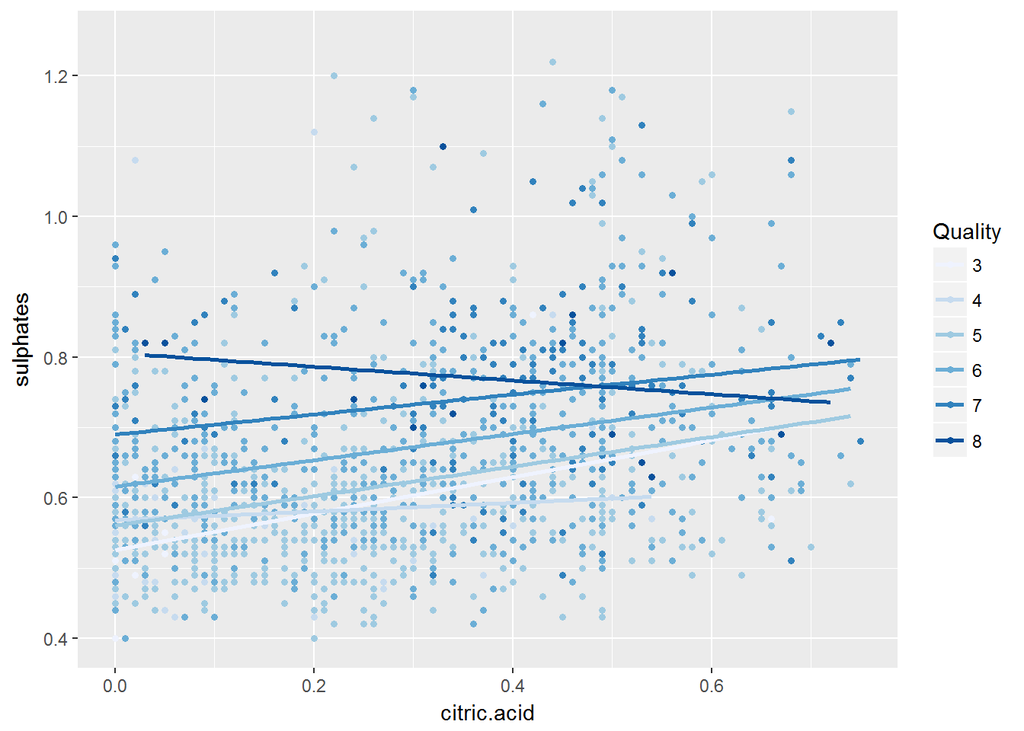

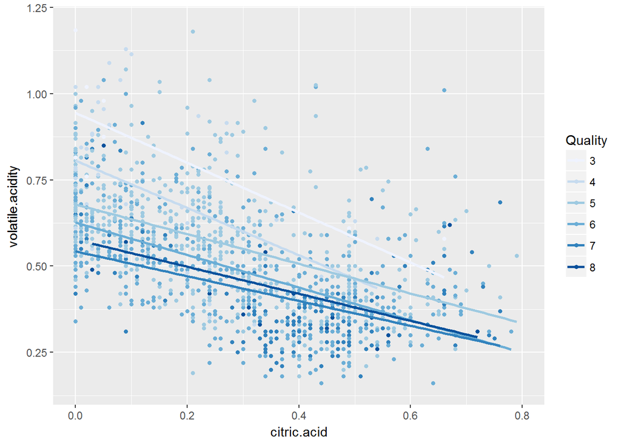

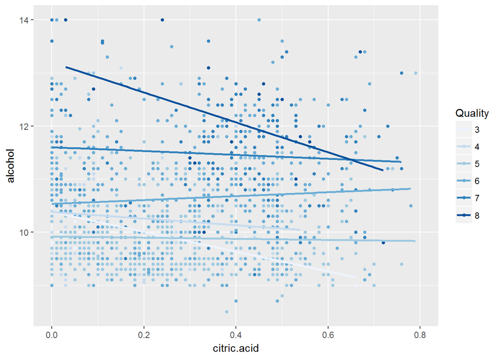

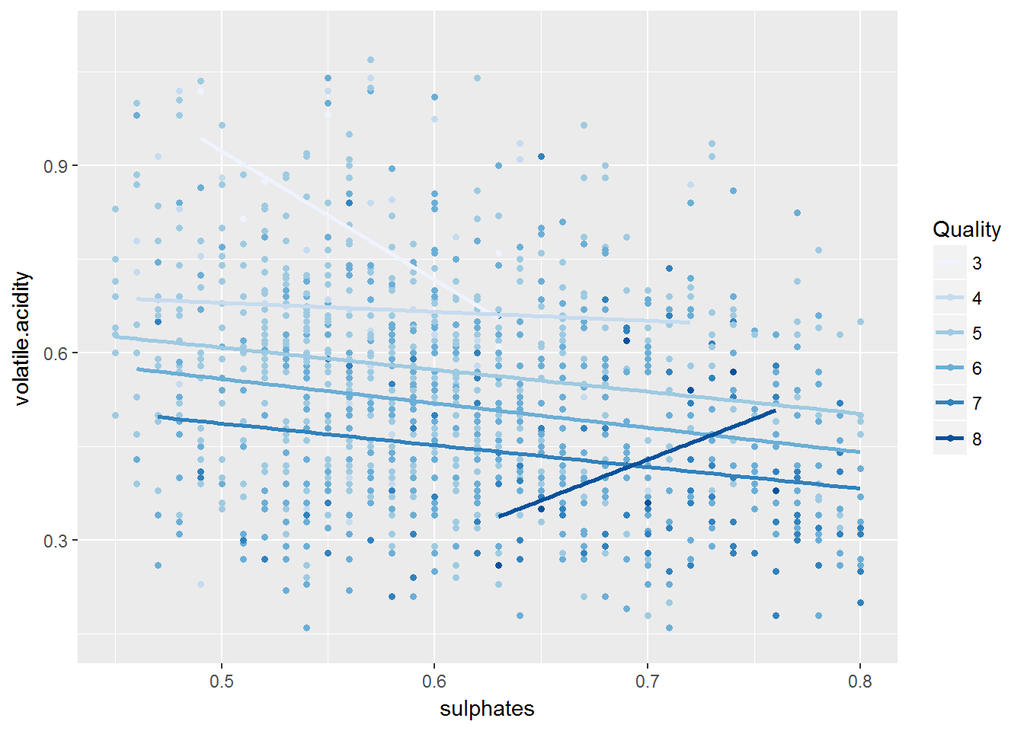

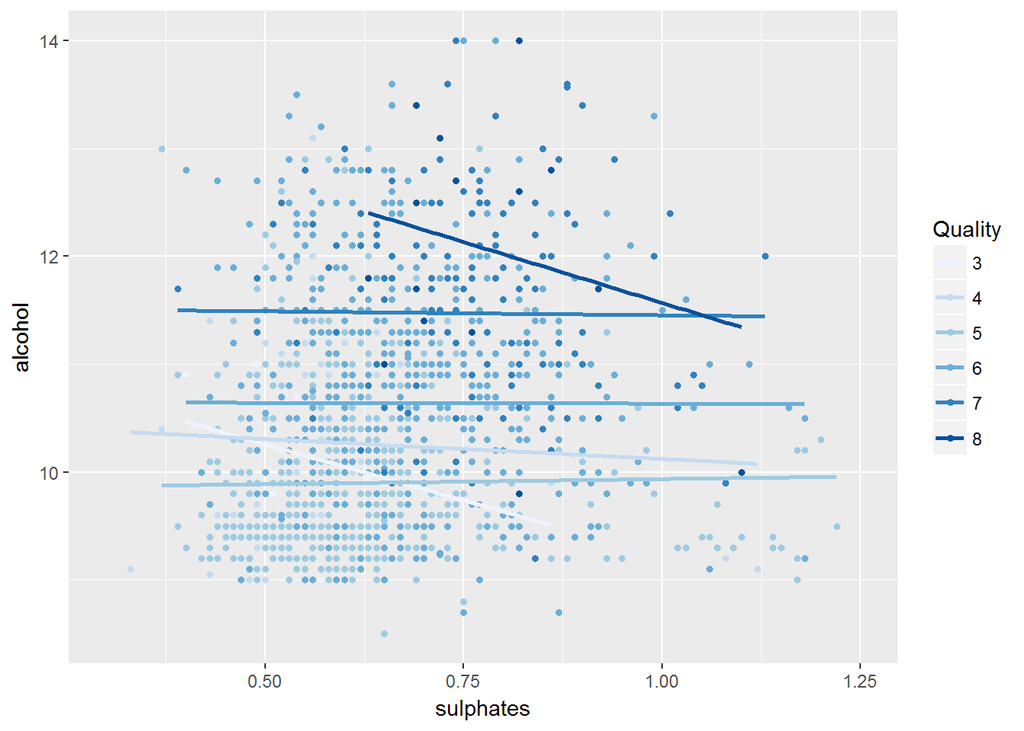

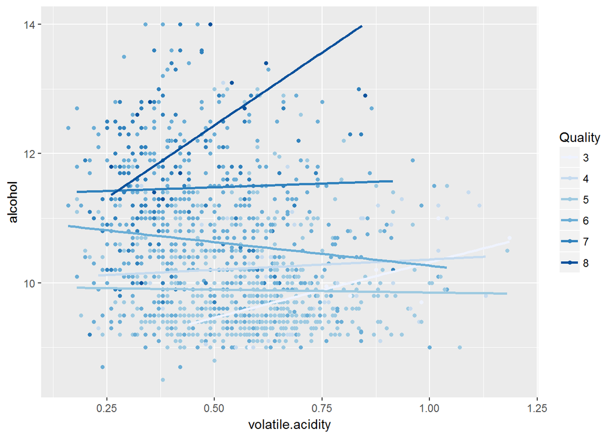

## 6. Final Plots and Summary

### 6.1 Alcohol and Wine Quality

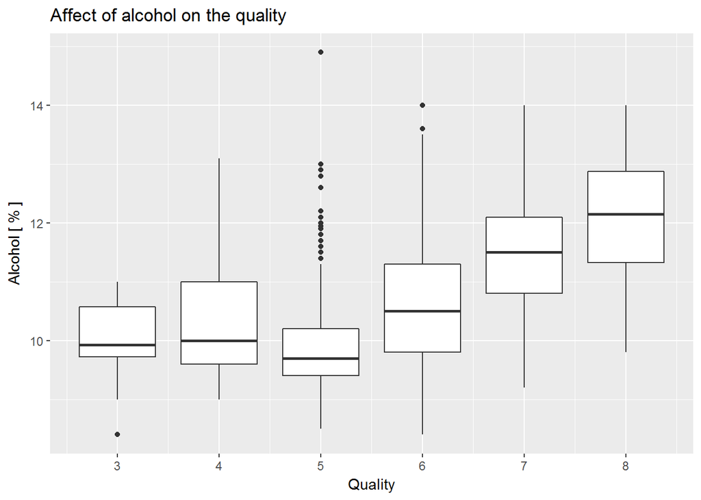

Since alcohol is probably the only one out of the 11 chemical propertys most people are familiar with, it is interesting to look at the affect it has on the overall wine quality. Higher alcohol level correlates with higher wine quality. Nevertheless the big outliers in the boxplot should be taken into account. Alcohol alone seem not make wines better.

### 6.2 Acids and Sulphates

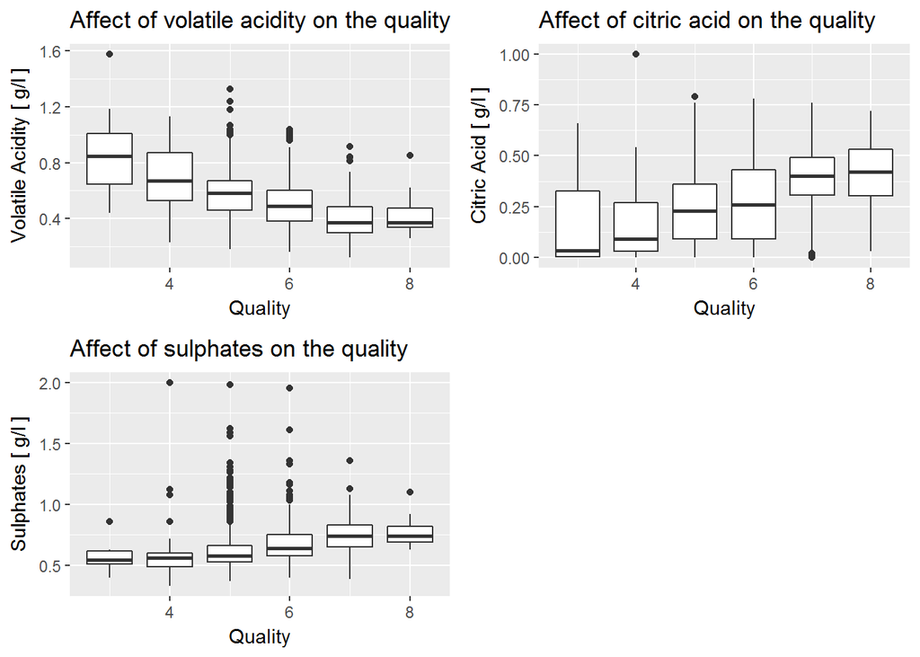

Further chemical propertys besides alcohol that have an significant affect on the quality are the concentrations of sulphates, volatile acidity and citric acid. While higher levels of sulphates and citric acid effect the quality positivly, the opposite occurs for the volatile acidity.

### 6.3 Alcohol and Volatile Acidity

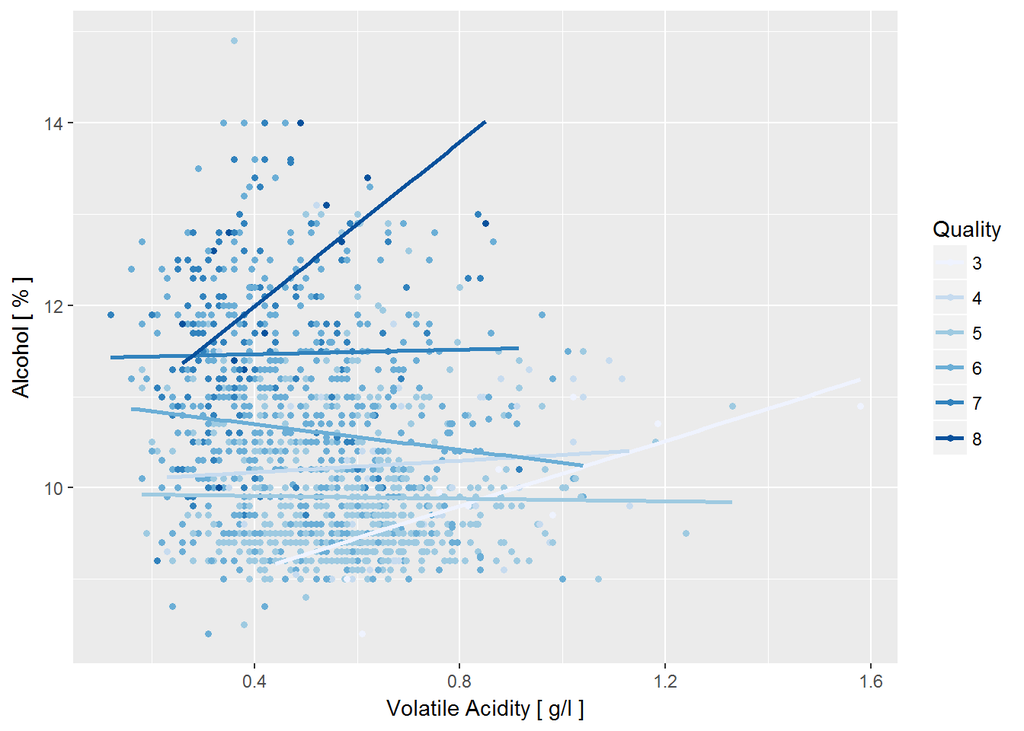

In my opinion this is the most telling plot because it shows the most distinguished boundaries between good and bad wine. This graph shows that the wine quality was strongly affected by volatile acidity and alcohol. It can be noticed that a combination of higher alcohol level and lower volatile acidity make better wine qualities.

## 7. Reflection

During the examination I could identify alcohol, sulphates, volatile acidity and citric acid as the variables with biggest affect on the wine quality. However there is not the one secret ingredient that makes the wine good or bad, furthermore it is a combination of each variables with it’s proper concentrations in the wine. Nevertheless I noticed some combination rules that can improve the wine quality. Especially having a higher level of alcohol while the volatile acidity level stay low makes a wine better.

Unfortunately the dataset does not contain wine with ratings above 8 and under 3. So I could not take a look on the extreme cases and determine the chemical property of the best and worst wines, what might have had some usefull insides.

An interesting idea for the future would be an implementation of a wine quality classifier. The classifier would learn on the provided dataset to predict the wine quality on given chemical features. An example for such a classifier would be a Support Vector Machine or Gaussian Naive Bayes.